# Loading and preprocessing the data

## Loading and preprocessing the data

The file *activity.csv* (unzipped from *repdata-data-activity.zip*) contains the data from a personal activity monitoring device. Each record has the number of steps taken in a 5-minute interval (possibly a NA), the date, and the interval ID. Only complete records are used for the first several experiments.

```r
activity <- read.csv ("activity.csv")
activity$date <- as.Date (activity$date)
complete.activity <- activity[complete.cases (activity),]
```

## What is mean total number of steps taken per day?

The plot shows a histogram of the total number of steps taken each day.

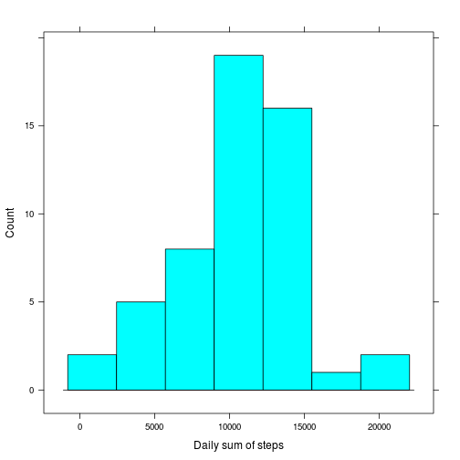

```r
library (lattice)
sum.steps <- aggregate (complete.activity$steps, by = list (complete.activity$date), FUN = sum)[2]
histogram (sum.steps$x, xlab = "Daily sum of steps", type = c ("count"))
```

The mean and median of the total number of steps taken per day:

```r
c (mean (sum.steps$x), median (sum.steps$x))
```

```
## [1] 10766.19 10765.00
```

The meand and the median are very close–the distribution is symmetric.

## What is the average daily activity pattern?

The plot shows the average number of steps taken for each interval.

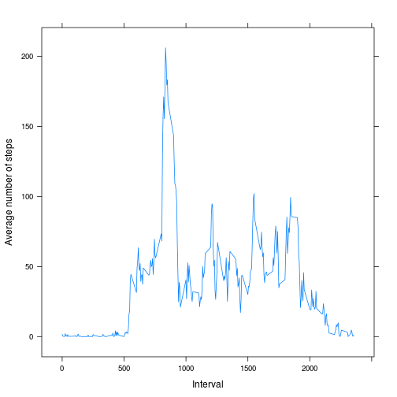

```r
steps.by.interval <- aggregate (complete.activity$steps, by = list (complete.activity$interval),
                                FUN = mean)
xyplot (x ~ Group.1, data = steps.by.interval, type = "l",
        xlab = "Interval", ylab = "Average number of steps")
```

Which 5-minute interval, on average, contains the maximum number of steps?

```r
most.steps <- which.max (steps.by.interval$x)
busiest.interval <- steps.by.interval[most.steps, 1]
busiest.interval
```

```
## [1] 835
```

## Imputing missing values

The total number of missing values in the dataset:

```r
dim (activity)[1] - dim (complete.activity)[1]
```

```
## [1] 2304
```

Replace a missing number of steps by the average number of steps for this interval. (*NB*: Using the average value for the day would not work, as there are no valid records for the first day of observations.)

```r
mean.steps <- aggregate (complete.activity$steps, by = list (complete.activity$interval), FUN = mean)
clean.activity <- merge (activity, mean.steps, by.x = "interval", by.y = "Group.1")
clean.activity$steps[is.na (clean.activity$steps)] <- clean.activity$x[is.na (clean.activity$steps)]
```

The plot shows a histogram of the total number of steps taken each day for the dataset with the imputed data.

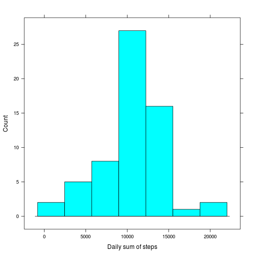

```r
clean.sum.steps <- aggregate (clean.activity$steps, by = list (clean.activity$date), FUN = sum)[2]
histogram (clean.sum.steps$x, xlab = "Daily sum of steps", type = c ("count"))
```

The mean and median of the total number of steps taken per day, with and without missing data:

```r
rbind (c (mean (sum.steps$x), median (sum.steps$x)),
  c (mean (clean.sum.steps$x), median (clean.sum.steps$x)))
```

```
##          [,1]     [,2]
## [1,] 10766.19 10765.00
## [2,] 10766.19 10766.19
```

The mean values did not change, which is explained by the fact that the missing values were replaced by the mean values by the interval. The median increased insignificantly.

## Are there differences in activity patterns between weekdays and weekends?

I created a new factor variable with two levels – “weekday” and “weekend.”

```r
clean.activity$weekend <- ifelse (weekdays (clean.activity$date) %in% c ("Saturday","Sunday"),
                                  "weekend",  "weekday")
clean.activity$weekend = as.factor (clean.activity$weekend)
```

The panel plot shows the number of steps taken for each interval, averaged across all weekday days or weekend days:

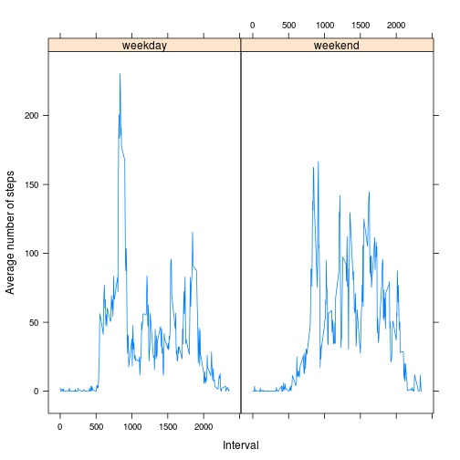

```r
clean.steps.by.interval <- aggregate (clean.activity$steps,
                                      by = list (clean.activity$interval, clean.activity$weekend),
                                FUN = mean)
xyplot (x ~ Group.1 | Group.2, data = clean.steps.by.interval, type="l",
       xlab = "Interval", ylab = "Average number of steps")
```

The weekend activity is more heterogeneous (more evenly spread across the intervals). The weekday activity is disproportionately concentrated around the 800th interval.